# REFERENCE GENES IN *Heliconius erato lativitta*

DATA ANALYSIS

Angel Ojeda

2026-06-28

Angel Ojeda - `angel.ojeda@ikiam.edu.ec` - Universidad Regional Amazónica IKIAM, Tena (Ecuador)

Paola Calderón - `pcalderon@stri.pa` - Instituto Smithsoniano de investigaciones tropicales, Gamboa (Panamá)

Joshué Ruiz - `joshue.ruiz@ikiam.edu.ec` - Universidad Regional Amazónica IKIAM, Tena (Ecuador)

Leo Camino - `lcamino@stri.pa` - Instituto Smithsoniano de investigaciones tropicales, Gamboa (Panamá)

Shane Wright - `dswright@bio.lmu.de` - Munich University (Germany)

Caroline Bacquet - `caroline.bacquet@ikiam.edu.ec` - Universidad Regional Amazónica IKIAM, Tena (Ecuador)

# 1. Ct Analysis

## 1.1. Ct Summary

Summary statistics: Ct values

|  | Gene | Treatment | Sex | Tissue | Ct |
| --- | --- | --- | --- | --- | --- |
|  | ACT1 : 54 | Cold :162 | Female:243 | A:162 | Min. :14.32 |
|  | ACT2 : 54 | Control:162 | Male :243 | H:162 | 1st Qu.:20.52 |
|  | AK : 54 | Heat :162 | NA | T:162 | Median :23.48 |
|  | ANX : 54 | NA | NA | NA | Mean :23.74 |
|  | eEfa1 : 54 | NA | NA | NA | 3rd Qu.:26.77 |
|  | GAPDH : 54 | NA | NA | NA | Max. :38.78 |
|  | (Other):162 | NA | NA | NA | NA |

## 1.2. Ct Boxplot

I made changes in this part, because we agreed to split the information in three boxplots i.e sex, tissue and treatment

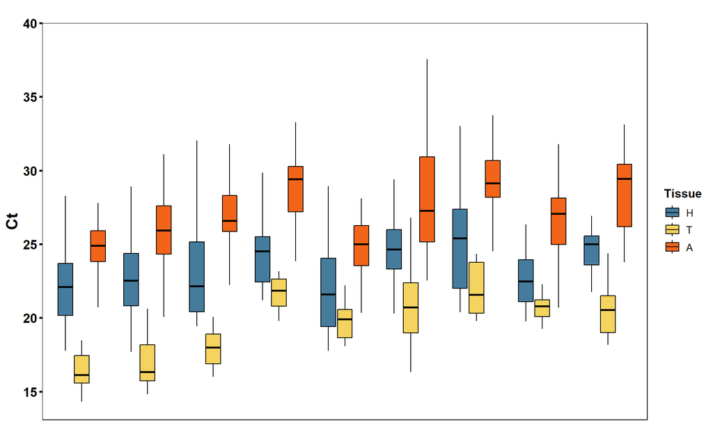

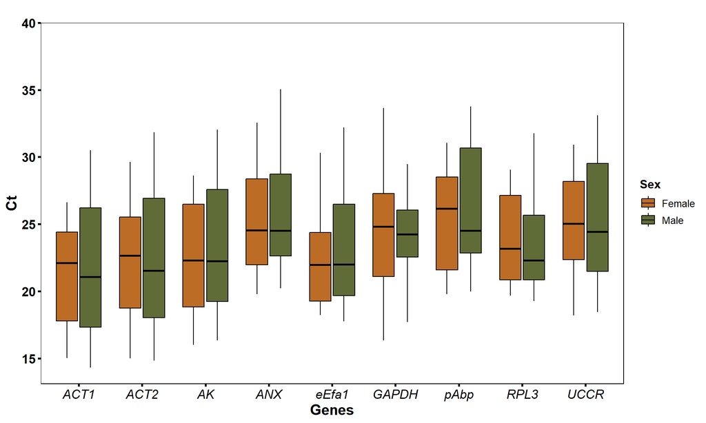

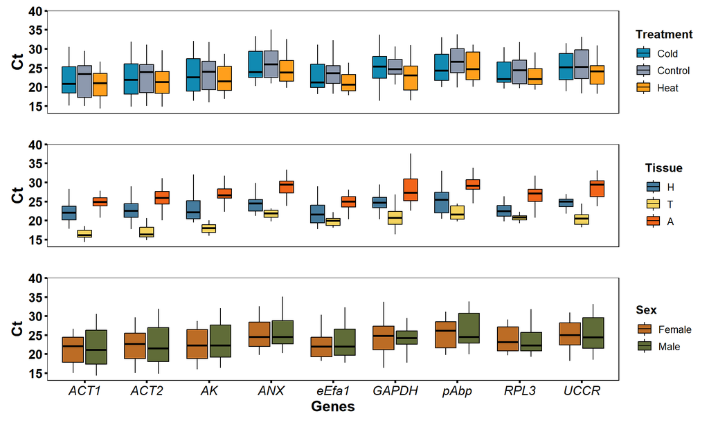

## 1.3. Ct Distribution

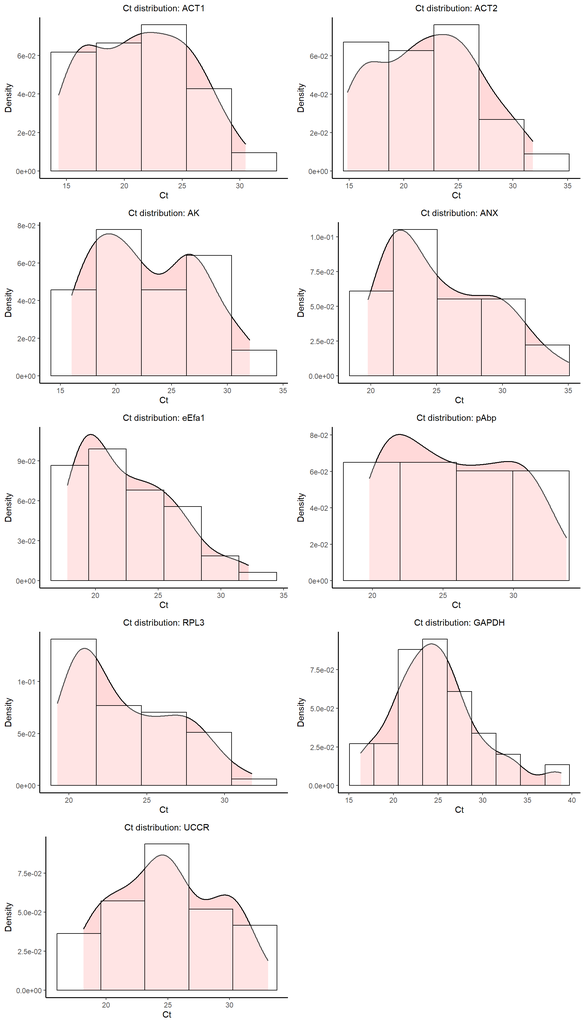

### 1.3.1. Ct Homogeneity of Variance (Levene Test)

> Tests whether Ct variance is homogeneous across Treatment × Sex × Tissue for each gene. A **significant result** (p < 0.05) indicates heteroscedasticity: relevant for model selection.

Levene Test: Ct homogeneity of variance by gene

| Gene | F_value | Pr_F | Signif |
| --- | --- | --- | --- |
| ACT1 | 4.708e-01 | 9.506e-01 | ns |
| ACT2 | 5.719e-01 | 8.907e-01 | ns |
| AK | 5.596e-01 | 8.993e-01 | ns |
| ANX | 5.839e-01 | 8.819e-01 | ns |
| eEfa1 | 7.040e-01 | 7.782e-01 | ns |
| pAbp | 7.324e-01 | 7.505e-01 | ns |
| RPL3 | 4.043e-01 | 9.755e-01 | ns |
| GAPDH | 5.794e-01 | 8.852e-01 | ns |
| UCCR | 6.980e-01 | 7.839e-01 | ns |

## 1.4. Ct GLM Analysis

> **Model specification:** `Ct ~ predictors` with family selected automatically by AIC comparison in section 1.4.0 (consensus across all genes). Type II Likelihood Ratio (LR) tests are used for all terms.

### 1.4.0. GLM Family Selection

> Candidate families: `Gamma(log)`, `Gamma(inverse)`, `Gaussian(identity)`. All are valid because Ct values are strictly positive (range: 14.3 – 38.8). The winning AIC per gene is highlighted in **green**.

Supplementary: Family selection AIC per gene (additive model)

| Gene | Gamma(log) | Gamma(inverse) | Gaussian(identity) | Best |
| --- | --- | --- | --- | --- |
| ACT1 | 275.35 | 274.32 | 278.16 | Gamma(inverse) |
| ACT2 | 285.4 | 284.58 | 287.68 | Gamma(inverse) |
| AK | 284.95 | 284.21 | 287.89 | Gamma(inverse) |
| ANX | 279.43 | 278.56 | 282.11 | Gamma(inverse) |
| eEfa1 | 284.66 | 284.1 | 288.71 | Gamma(inverse) |
| pAbp | 287.12 | 286.98 | 287.79 | Gamma(inverse) |
| RPL3 | 259.98 | 260.07 | 263.69 | Gamma(log) |
| GAPDH | 296.71 | 297.25 | 303.58 | Gamma(log) |
| UCCR | 263.76 | 263.43 | 264.57 | Gamma(inverse) |

### 1.4.1. Interaction Model: `Treatment * Sex * Tissue`

#### ANOVA Results (Type II LR Test)

Interaction GLM: ANOVA Type II LR test (Ct ~ Treatment * Sex * Tissue)

Gene

Term

Df

LR_Chisq

Pr_Chi

Signif

ACT1

Treatment

2e+00

2.5310e+00

2.822e-01

ns

ACT1

Sex

1e+00

5.5200e-01

4.574e-01

ns

ACT1

Tissue

2e+00

8.5413e+01

0.000e+00

***

ACT1

Treatment:Sex

2e+00

1.5097e+01

5.000e-04

***

ACT1

Treatment:Tissue

4e+00

4.5190e+00

3.403e-01

ns

ACT1

Sex:Tissue

2e+00

1.4390e+00

4.871e-01

ns

ACT1

Treatment:Sex:Tissue

4e+00

3.0040e+00

5.571e-01

ns

ACT2

Treatment

2e+00

2.7870e+00

2.482e-01

ns

ACT2

Sex

1e+00

2.3300e-01

6.292e-01

ns

ACT2

Tissue

2e+00

7.8884e+01

0.000e+00

***

ACT2

Treatment:Sex

2e+00

1.4608e+01

7.000e-04

***

ACT2

Treatment:Tissue

4e+00

3.3120e+00

5.070e-01

ns

ACT2

Sex:Tissue

2e+00

1.4530e+00

4.836e-01

ns

ACT2

Treatment:Sex:Tissue

4e+00

3.2130e+00

5.228e-01

ns

AK

Treatment

2e+00

2.5410e+00

2.806e-01

ns

AK

Sex

1e+00

6.6000e-01

4.166e-01

ns

AK

Tissue

2e+00

6.0659e+01

0.000e+00

***

AK

Treatment:Sex

2e+00

8.4690e+00

1.450e-02

AK

Treatment:Tissue

4e+00

4.2920e+00

3.679e-01

ns

AK

Sex:Tissue

2e+00

7.4100e-01

6.903e-01

ns

AK

Treatment:Sex:Tissue

4e+00

1.8310e+00

7.668e-01

ns

ANX

Treatment

2e+00

2.1380e+00

3.433e-01

ns

ANX

Sex

1e+00

6.9700e-01

4.037e-01

ns

ANX

Tissue

2e+00

3.7107e+01

0.000e+00

***

ANX

Treatment:Sex

2e+00

9.2800e-01

6.288e-01

ns

ANX

Treatment:Tissue

4e+00

1.0668e+01

3.060e-02

ANX

Sex:Tissue

2e+00

1.2500e-01

9.395e-01

ns

ANX

Treatment:Sex:Tissue

4e+00

3.0000e-02

9.999e-01

ns

eEfa1

Treatment

2e+00

3.9260e+00

1.404e-01

ns

eEfa1

Sex

1e+00

8.6900e-01

3.514e-01

ns

eEfa1

Tissue

2e+00

1.8757e+01

1.000e-04

***

eEfa1

Treatment:Sex

2e+00

1.0875e+01

4.400e-03

eEfa1

Treatment:Tissue

4e+00

4.3680e+00

3.585e-01

ns

eEfa1

Sex:Tissue

2e+00

6.3700e-01

7.271e-01

ns

eEfa1

Treatment:Sex:Tissue

4e+00

1.0140e+00

9.077e-01

ns

pAbp

Treatment

2e+00

1.6020e+00

4.488e-01

ns

pAbp

Sex

1e+00

1.8680e+00

1.717e-01

ns

pAbp

Tissue

2e+00

3.4822e+01

0.000e+00

***

pAbp

Treatment:Sex

2e+00

7.2960e+00

2.600e-02

pAbp

Treatment:Tissue

4e+00

2.8790e+00

5.783e-01

ns

pAbp

Sex:Tissue

2e+00

8.9000e-01

6.408e-01

ns

pAbp

Treatment:Sex:Tissue

4e+00

1.4050e+00

8.433e-01

ns

RPL3

Treatment

2e+00

2.2180e+00

3.299e-01

ns

RPL3

Sex

1e+00

9.9000e-02

7.532e-01

ns

RPL3

Tissue

2e+00

3.8794e+01

0.000e+00

***

RPL3

Treatment:Sex

2e+00

7.0240e+00

2.980e-02

RPL3

Treatment:Tissue

4e+00

1.6000e+00

8.087e-01

ns

RPL3

Sex:Tissue

2e+00

2.5740e+00

2.762e-01

ns

RPL3

Treatment:Sex:Tissue

4e+00

1.3380e+00

8.550e-01

ns

GAPDH

Treatment

2e+00

9.1900e+00

1.010e-02

GAPDH

Sex

1e+00

7.0000e-03

9.335e-01

ns

GAPDH

Tissue

2e+00

4.0146e+01

0.000e+00

***

GAPDH

Treatment:Sex

2e+00

6.8140e+00

3.310e-02

GAPDH

Treatment:Tissue

4e+00

2.8840e+00

5.774e-01

ns

GAPDH

Sex:Tissue

2e+00

3.9100e-01

8.223e-01

ns

GAPDH

Treatment:Sex:Tissue

4e+00

5.1150e+00

2.757e-01

ns

UCCR

Treatment

2e+00

5.0630e+00

7.950e-02

.

UCCR

Sex

1e+00

4.0000e-03

9.485e-01

ns

UCCR

Tissue

2e+00

8.6495e+01

0.000e+00

***

UCCR

Treatment:Sex

2e+00

1.3357e+01

1.300e-03

UCCR

Treatment:Tissue

4e+00

1.1120e+00

8.923e-01

ns

UCCR

Sex:Tissue

2e+00

1.7110e+00

4.250e-01

ns

UCCR

Treatment:Sex:Tissue

4e+00

7.4500e-01

9.457e-01

ns

#### Heatmap: P-values by Gene and Condition

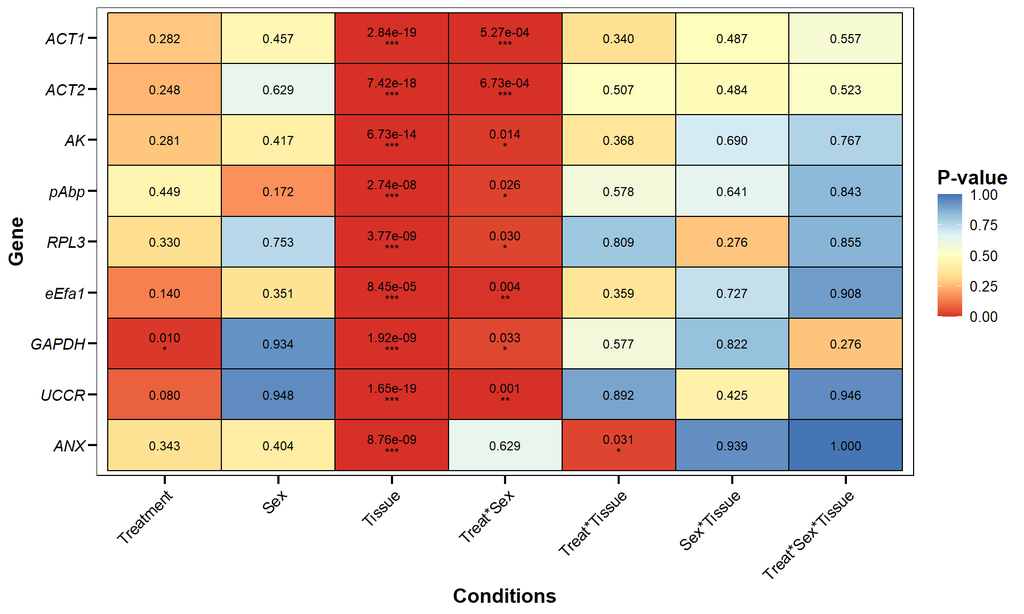

#### Q-Q Plots of Residuals

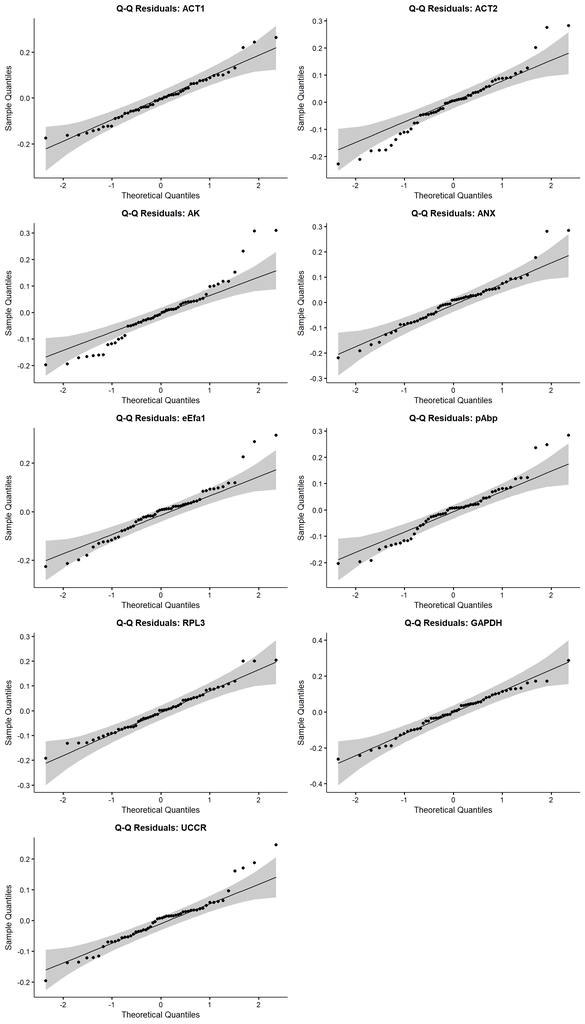

#### Residual Histograms

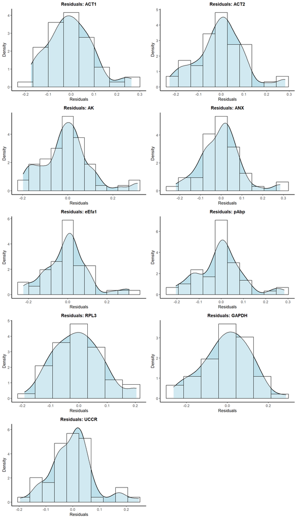

### 1.4.2. Model Comparison: AIC (Additive vs. Interaction)

> **Interpretation:** ΔAIC > 2 favours the interaction model; |ΔAIC| < 2 indicates equivalent support and the simpler (additive) model is preferred by parsimony. This table is provided as supplementary justification for model selection.

AIC comparison: Additive vs Interaction Ct GLMs

| Gene | AIC_Additive | AIC_Interaction | Delta_AIC | Preferred |
| --- | --- | --- | --- | --- |
| ACT1 | 274.32 | 269.70 | 4.62 | Interaction |
| ACT2 | 284.58 | 281.24 | 3.34 | Interaction |
| AK | 284.21 | 288.15 | -3.94 | Additive |
| ANX | 278.56 | 286.77 | -8.21 | Additive |
| eEfa1 | 284.10 | 286.29 | -2.19 | Additive |
| pAbp | 286.98 | 294.58 | -7.60 | Additive |
| RPL3 | 260.07 | 267.03 | -6.96 | Additive |
| GAPDH | 297.25 | 302.46 | -5.21 | Additive |
| UCCR | 263.43 | 265.67 | -2.24 | Additive |

> 📊 **Automatic AIC summary:** The additive model was preferred in **7 of 9** genes (|ΔAIC| > 2), indicating that interactions between Treatment, Sex, and Tissue do not explain substantial additional variance in Ct values. This supports interpreting the effects of each factor independently.

# 2. Relative Expression Analysis (EGR)

> **Context:** EGR values result from RefFinder / geNorm rankings. The `Quality` variable classifies genes as “worst” or “best” reference genes based on their stability scores. The goal is to compare how expression results change when normalizing with each set.

## 2.1. EGR Summary

Summary statistics: EGR data

|  | Gene | Quality | Treatment | Sex | Tissue | EGR | Log_EGR |
| --- | --- | --- | --- | --- | --- | --- | --- |
|  | HSP90:108 | best :54 | Cold :36 | Female:54 | A:36 | Min. : 0.001 | Min. :-3.0211 |
|  | NA | worst:54 | Control:36 | Male :54 | H:36 | 1st Qu.: 0.488 | 1st Qu.:-0.3119 |
|  | NA | NA | Heat :36 | NA | T:36 | Median : 3.084 | Median : 0.4890 |
|  | NA | NA | NA | NA | NA | Mean : 93.813 | Mean : 0.4817 |
|  | NA | NA | NA | NA | NA | 3rd Qu.: 20.310 | 3rd Qu.: 1.3076 |
|  | NA | NA | NA | NA | NA | Max. :3969.092 | Max. : 3.5987 |

## 2.2. EGR Distribution

### 2.2.1. Raw EGR Distribution

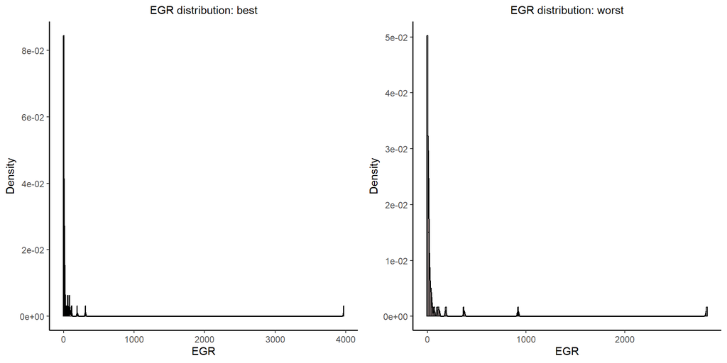

### 2.2.2. Log(EGR) Distribution

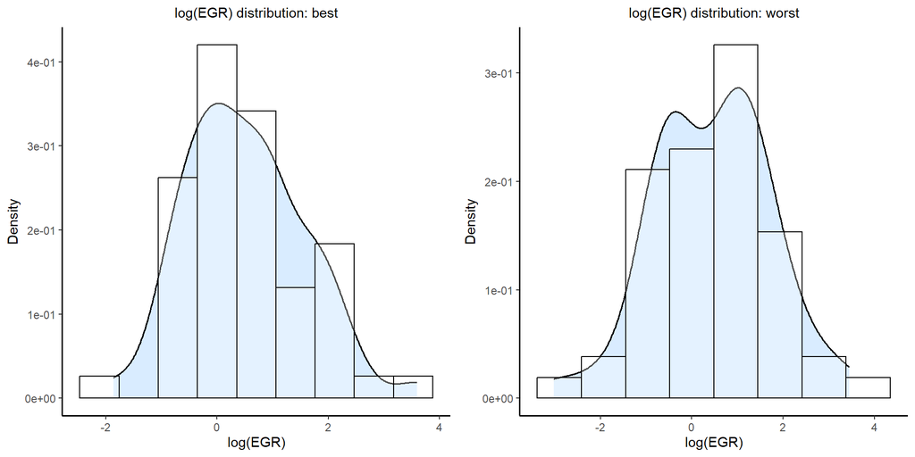

## 2.3. EGR Homogeneity of Variance (Levene Test)

### 2.3.1. Raw EGR

Levene Test: EGR homogeneity of variance by gene quality

| Quality | F_value | Pr_F | Signif |
| --- | --- | --- | --- |
| best | 1.1535e+00 | 3.473e-01 | ns |
| worst | 1.1665e+00 | 3.374e-01 | ns |

### 2.3.2. Log(EGR)

Levene Test: log(EGR) homogeneity of variance by gene quality

| Quality | F_value | Pr_F | Signif |
| --- | --- | --- | --- |
| best | 3.482e-01 | 9.885e-01 | ns |
| worst | 4.145e-01 | 9.724e-01 | ns |

## 2.4. Barplots: Worst vs Best Reference Genes

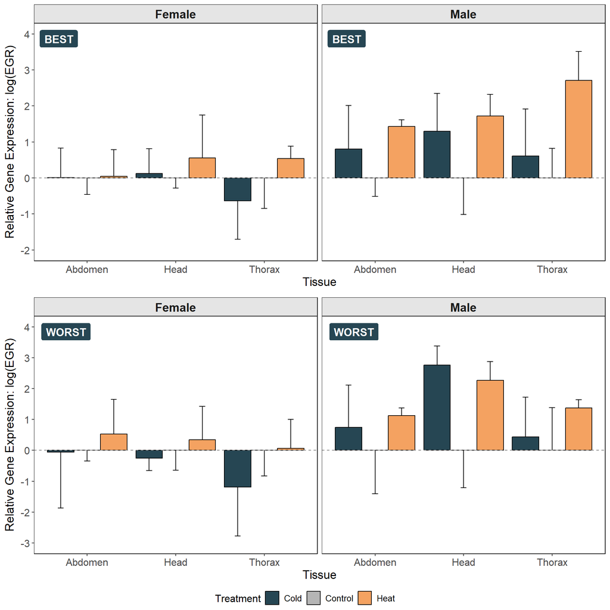

## 2.5. Log(EGR) GLM Analysis

> **Family auto-selected: `gaussian(link = "identity")`.** Log(EGR) contains negative values (range: -3.02 – 3.6), which are incompatible with Gamma distributions (requiring Y > 0 strictly). No AIC family comparison is needed: Gaussian is the only valid candidate. This is equivalent to a standard linear model; Type II LR tests are used for effects.

### 2.5.1. Interaction Model: `Treatment * Sex * Tissue`

Interaction GLM: ANOVA Type II LR test (log(EGR) ~ Treatment * Sex * Tissue)

Quality

Term

Df

LR_Chisq

Pr_Chi

Signif

best

Treatment

2e+00

1.8216e+01

1.000e-04

***

best

Sex

1e+00

1.4886e+01

1.000e-04

***

best

Tissue

2e+00

7.3600e-01

6.922e-01

ns

best

Treatment:Sex

2e+00

8.2560e+00

1.610e-02

best

Treatment:Tissue

4e+00

4.8850e+00

2.993e-01

ns

best

Sex:Tissue

2e+00

6.3900e-01

7.267e-01

ns

best

Treatment:Sex:Tissue

4e+00

8.1100e-01

9.370e-01

ns

worst

Treatment

2e+00

7.2920e+00

2.610e-02

worst

Sex

1e+00

1.2766e+01

4.000e-04

***

worst

Tissue

2e+00

4.4720e+00

1.069e-01

ns

worst

Treatment:Sex

2e+00

6.9700e+00

3.060e-02

worst

Treatment:Tissue

4e+00

3.6930e+00

4.491e-01

ns

worst

Sex:Tissue

2e+00

2.8100e+00

2.453e-01

ns

worst

Treatment:Sex:Tissue

4e+00

1.7050e+00

7.898e-01

ns

#### Q-Q Plots of Residuals

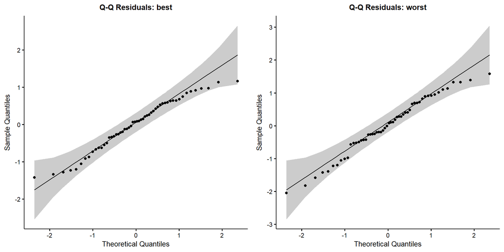

#### Residual Histograms

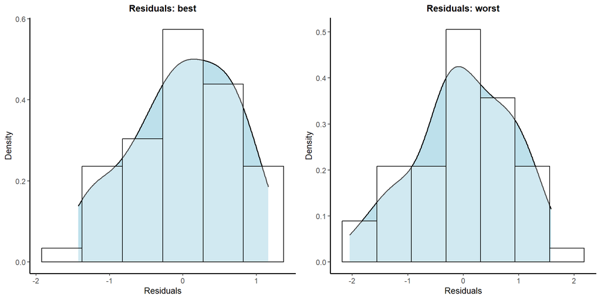

### 2.5.2. Model Comparison: AIC (Additive vs. Interaction)

AIC comparison: Additive vs Interaction log(EGR) GLMs

| Quality | AIC_Additive | AIC_Interaction | Delta_AIC | Preferred |
| --- | --- | --- | --- | --- |
| best | 144.68 | 150.31 | -5.63 | Additive |
| worst | 170.69 | 175.69 | -5.00 | Additive |

> 📊 **Automatic AIC summary:** The additive model was preferred for **all 2** gene quality groups (|ΔAIC| > 2), indicating that interactions between Treatment, Sex, and Tissue do not improve the explanation of log(EGR) variance. Effects of each factor can be interpreted independently.